# Assignment 14: Twitters Mining with rtweet

*How to do it?*:

- Open the Rmarkdown file of this assignment (link) in Rstudio.
- Right under each **question**, insert a code chunk (you can use the hotkey `Ctrl + Alt + I` to add a code chunk) and code the solution for the question.
- `Knit` the rmarkdown file (hotkey: `Ctrl + Alt + K`) to export an html.
- Publish the html file to your Githiub Page.

*Submission*: Submit the link on Github of the assignment to Canvas

Sample Codes

1. Pick a keyword or hashtag. Download the data associated with the keyword/hashtag. Plot at least 10 plots to visualize the data associated with the keyword/hashtag. All plots should have titles and captions.

```r
keyword_search = 'United_States'

df <- search_tweets(q = keyword_search,
                        n = 18000,
                        include_rts = FALSE,
                        `-filter` = "replies",
                        lang = "en") %>%
  mutate(created_at = ymd_hms(format(created_at, tz = "US/Eastern")))

write_csv(df, 'twitter_data_america.csv')
```

```r
library(rtweet)
library(tidytext)
library(ggpubr)
library(tidyverse)
library(knitr)
library(lubridate)

df <- read_csv('twitter_data_america.csv')
```

```r
df %>%
  unnest_tokens(output = hashtag, input = text, token = "tweets") %>%
  filter(!hashtag %in% c("United_States",'America','infrastructure','bill'), str_detect(hashtag, "^#")) %>%
  count(hashtag, sort = TRUE) %>%
  head(10)
```

```
## # A tibble: 10 x 2
##    hashtag            n
##    <chr>          <int>
##  1 #america         114
##  2 #usa              31
##  3 #scotus           28
##  4 #roevwade         20
##  5 #games            19
##  6 #guncontrolnow    19
##  7 #nomore           19
##  8 #omicron          19
##  9 #apocalypse       18
## 10 #game             18
```

Plot 2:

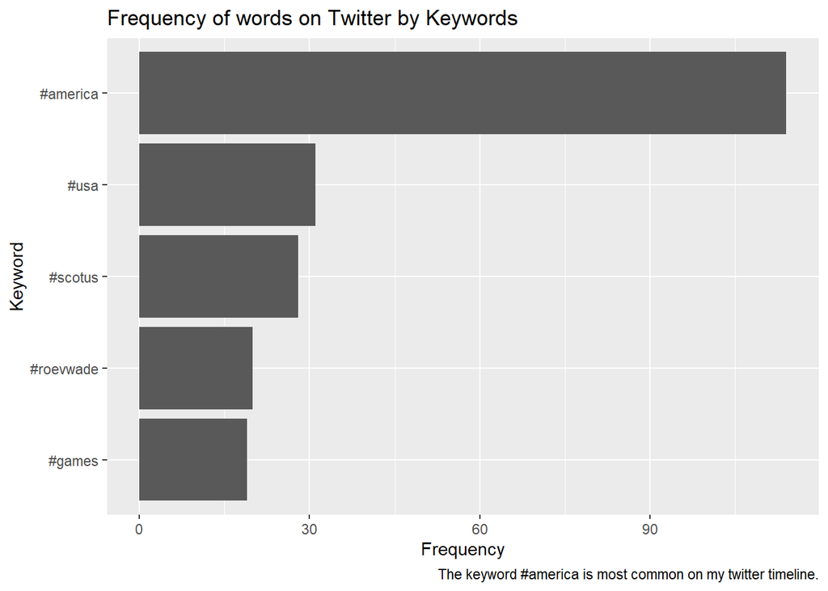

```r
df %>%
  unnest_tokens(output = hashtag, input = text, token = "tweets") %>%
  filter(!hashtag %in% c("United_States",'America','infrastructure','bill'), str_detect(hashtag, "^#")) %>%
  count(hashtag, sort = TRUE) %>%
  head(5) %>%
  ggplot(aes(x = n, y = reorder(hashtag, n)))+
  geom_col()+
  labs(x='Frequency',
       y = 'Keyword',
       title = 'Frequency of words on Twitter by Keywords',
       caption = 'The keyword #america is most common on my twitter timeline.')
```

Plot 3:

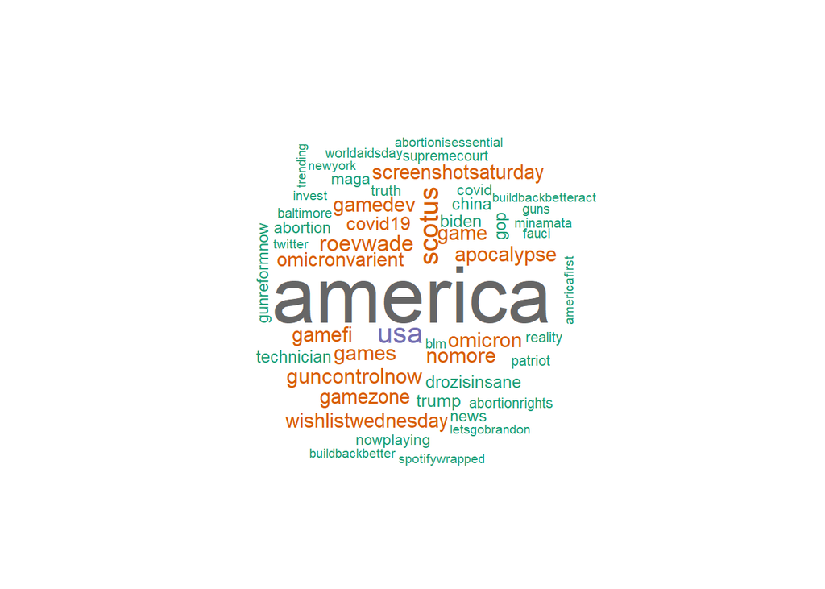

```r
library(RColorBrewer)

pal <- brewer.pal(8,"Dark2")
library(wordcloud)

df %>%
  unnest_tokens(output = hashtag, input = text, token = "tweets") %>%
  filter(!hashtag %in% c("United_States",'America','infrastructure','bill'), str_detect(hashtag, "^#")) %>%
  count(hashtag, sort = TRUE) %>%
  mutate(hashtag = str_remove(hashtag, '#')) %>%
  filter(hashtag != 'bill') %>%
  with(wordcloud(hashtag, n, random.order = FALSE, max.words = 50, colors = pal))
```

Plot 4:

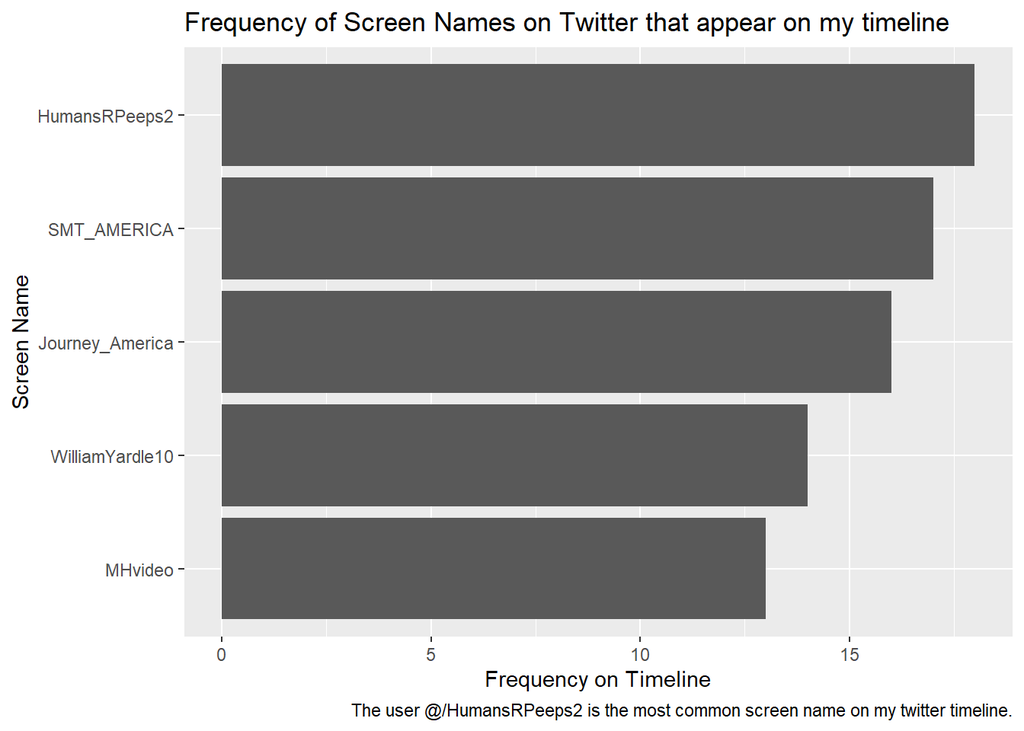

```r
df %>%
  count(screen_name, sort = TRUE) %>%
  head(5) %>%
  ggplot(aes(x = n, y = reorder(screen_name, n)))+
  geom_col()+
  labs(x='Frequency on Timeline',
       y = 'Screen Name',
       title = 'Frequency of Screen Names on Twitter that appear on my timeline',
       caption = 'The user @/HumansRPeeps2 is the most common screen name on my twitter timeline.')
```

Plot 5:

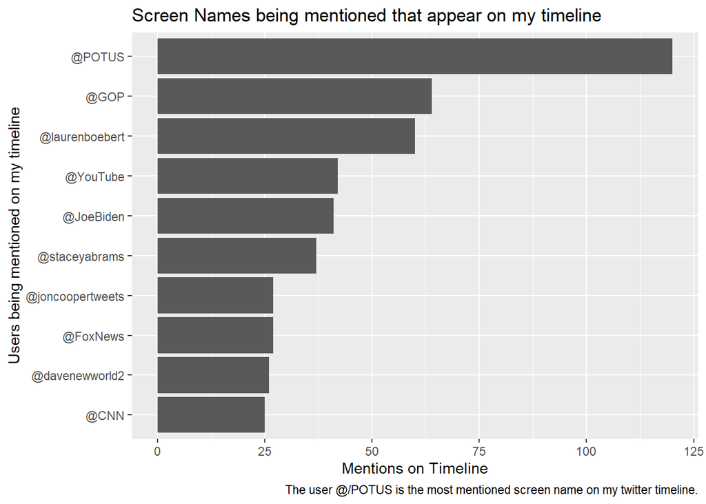

```r
df %>%
  unnest_tokens(mentions, text, "tweets", to_lower = FALSE) %>%
  filter(str_detect(mentions, "^@")) %>%
  count(mentions, sort = TRUE) %>%
  head(10) %>%
  ggplot(aes(x = n, y = reorder(mentions, n)))+
  geom_col()+
  labs(x='Mentions on Timeline',
       y = 'Users being mentioned on my timeline',
       title = 'Screen Names being mentioned that appear on my timeline',
       caption = 'The user @/POTUS is the most mentioned screen name on my twitter timeline.')
```